# Molecular Marker Assisted Plant Breeding

One Stage vs. Two Stages

Felipe Ferrão

University of Florida

**Objectives:**

- 60 minutes of hands-on
- Comparing one vs. two stages
- Running examples in coffee

**Extra information**

- [HOS 6236 – Website](https://lfelipe-ferrao.github.io/class/mas/)
- About the [author](https://lfelipe-ferrao.github.io/)
- About the [UF/IFAS Plant Breeding](https://programs.ifas.ufl.edu/plant-breeding/)

# Introduction

When fitting **genomic selection models** or other statistical genetic models that involve **sparse or complex experimental designs**, breeders and analysts often face challenges related to data fitting, model convergence, and result interpretation. These difficulties arise because breeding data frequently come from heterogeneous experiments that vary across time, space, and management conditions, making it difficult to model all relevant sources of variation simultaneously.

For instance, consider the **blueberry breeding program at the University of Florida**, which operates across a complex network of trials. Plants or genotypes are evaluated under diverse environmental conditions, introducing variability at both temporal and spatial levels. Key sources of variation include:

- **Within-season variation:** Berries may be harvested early, mid, or late in the season.
- **Seasonal effects:** Data are collected across multiple years, each with distinct climatic conditions.
- **Physiological effects:** Experimental plants often differ in age or developmental stage.
- **Spatial variation:** Row and column effects are commonly observed within field trials.
- **Experimental design effects:** Technical and biological replicates add another layer of complexity.
- **Site effects:** Experiments conducted across multiple locations capture diverse growing conditions.

Incorporating all these sources of variation—and their possible interactions—into a single statistical model is a significant challenge. This complexity has motivated the adoption of **one-stage** and **two-stage** genomic selection analyses across multiple crops. These approaches offer different strategies to manage data heterogeneity while improving the robustness and interpretability of genomic predictions.

# Theory

## One vs. Two Stage analysis

In a **one-stage genomic selection analysis**, all available data—phenotypes, genotypes, and fixed effects—are analyzed simultaneously within a single statistical model. This approach directly links genomic information to observed phenotypes, accounting for environmental and experimental effects in one step. It is often preferred (gold standard) for its statistical efficiency and ability to handle unbalanced or complex datasets.

In contrast, a **two-stage genomic selection analysis** separates the process into two steps:

- In the first stage, adjusted phenotypic values or estimated breeding values (EBVs) are obtained from a traditional mixed model that accounts for non-genetic effects.
- In the second stage, these adjusted values are used as response variables in the genomic prediction model. This approach is computationally simpler and more flexible for combining data from multiple environments or experiments.

Both strategies are useful in genomic prediction, and the choice between them depends on data structure, computational resources, and the objectives of the breeding program.

## Fully-efficient two-stage models

The use of two-stage analysis is more popular in the GS literature, since it can simplify the problem. There are several points when considering a two stage analysis that we will address here separately, including:

- Shold we use the phenotype effects as fixed or random effects in the first stage?
- How to make one and two-stages equivalent models?

### Random vs. Fixed Effects

In the first stage, genotypic effects can be considered either as fixed or random effects. The literature is somewhat controversial on this point, with studies adopting different strategies. More recently, [Holland and Piepho (2025)](https://academic.oup.com/g3journal/article/14/12/jkae250/7903473) has presented a compelling argument for why using BLUEs (fixed effects) in the first stage may be a better option.

Here is my perspective on the topic:

1. **Experimental design:** If you have an orthogonal experimental design with low levels of missing data, treating genotypic effects as fixed or random (assuming they are normally and independently distributed) will not drastically affect your genomic selection (GS) results.
2. **Internal testing:** For internal analyses, always compare the use of BLUEs and BLUPs and evaluate their impact on prediction accuracy. In my experience, the differences in results and GEBV rankings are usually minor.
3. **Pedigree matrices:** Avoid using pedigree relationship matrices in the first step. Individuals with more extensive pedigree information may experience different levels of shrinkage, which can introduce bias in the second-stage analyses.
4. **Publication bias:** Reviewers tend to prefer BLUE estimates over BLUP predictions in the first stage. This bias has been increasingly noticeable in recent literature.

### Two-stage approach

The use of two-stage analysis have been discussed by several authors, showing good insights and ideas. Below, I am listing the most important papers in this area, in my opinion:

- Gonzalez and Sanchez, 2025. Optimizing fully-efficient two-stage models for genomic selection using open-source software. [Link](https://plantmethods.biomedcentral.com/articles/10.1186/s13007-024-01318-9)
- Endelman, 2023. Fully efficient, two-stage analysis of multi-environment trials with directional dominance and multi-trait genomic selection. [Link](https://pmc.ncbi.nlm.nih.gov/articles/PMC10033618/)
- Piepho et al., (2012). A stage-wise approach for the analysis of multi-environment trials. [Link](https://onlinelibrary.wiley.com/doi/10.1002/bimj.201100219)
- Verbyla, 2023. On two-stage analysis of multi-environment trials. [Link](https://link.springer.com/article/10.1007/s10681-023-03248-4)

A good summary about the use of Stage-Wise analysis is presented below.

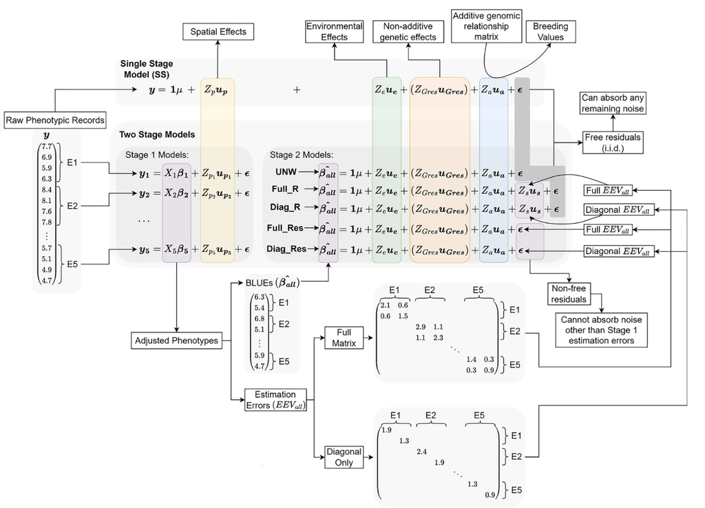

Stage-wise analysis presented by Gonzalez and Sanchez, 2025. The single-stage model is on top, with the different types of two-stage models below it. The stage 1 model is common to all types of two-stage models, which only differ on how the stage 2 model accounts for the stage 1 estimation error variance-covariance

# Hands-on

## Use of open-source analysis

A complete comparasion between methods and models are presented [here](https://github.com/TheRocinante-lab/Publications/tree/main/2024/Fernandez-Gonzalez_et_al_Fully_Efficient) by [Gonzalez and Sanchez, 2025.](https://plantmethods.biomedcentral.com/articles/10.1186/s13007-024-01318-9). The authors used several software and methods to describe the use of two-stage analysis, with the main results summarized int he sequence

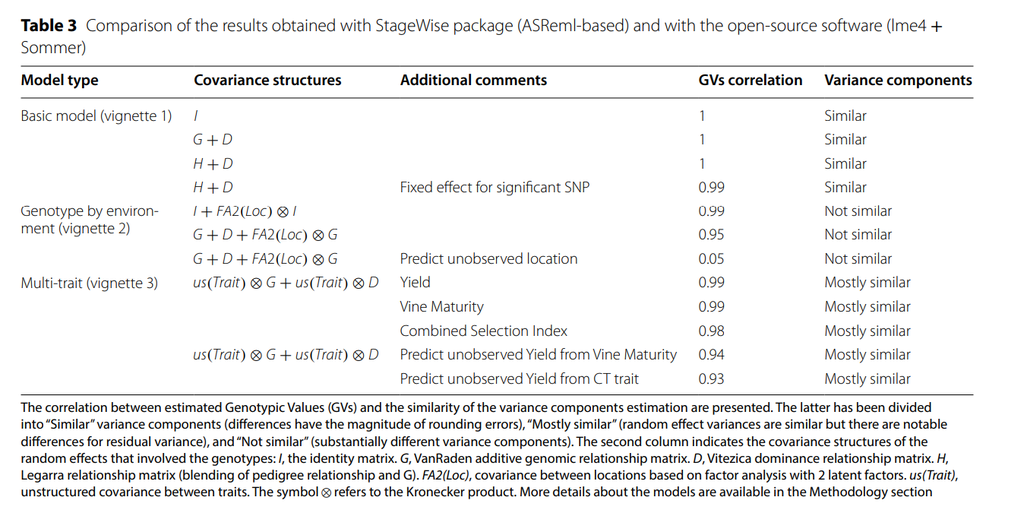

Stage-wise analysis presented by Gonzalez and Sanchez, 2025. Different vignettes presented on the website considering approaches for including weights from the stage 1 to the stage 2.

## Coffee data set

### Data Sources

Genotypic and phenotypic data from a coffee population consisting of 222 individuals and 58,000 SNP markers were used in the analyses. The genomic data were imported from an R workspace file (`coffee_example_222ind_58k.Rdata`), and the phenotypic data were retrieved from an Excel file (`coffee_phenotype.xlsx`).

### One-Stage Mixed Model Analysis (ASReml-R)

The one-stage model was fitted using the `ASReml-R` package, accounting simultaneously for fixed and random effects, as well as the genomic relationship among genotypes.

$$y = Xb + Z_1u + Z_2g + e$$

where:

- y is the vector of phenotypic observations (yield per plant, kg).
- Xb includes fixed effects for **Year** and **Block nested within Year**.
- $Z_{1u}$ represents the random genetic effects of individuals with ( $u \sim N(0, G\sigma^2_u$) ).
- $Z_{2g}$ represents the genotype-by-year interaction effects with ( $g \sim N(0, I\sigma^2_{ge}$) ).
- $e \sim N(0, I\sigma^2_e)$ is the residual error.

```r
library(asreml)
library(openxlsx)
library(dplyr)
library(AGHmatrix)

# download the data
load("/home/felipe/Dropbox (UFL)/classes/Molecular_Breeding/class5_GWAS/GWASmodels/coffee_example_222ind_58k.Rdata")

# Computing the G matrix
M1 <- M[, -c(1:3)]
G  <- Gmatrix(t(M1 + 1))
```

```
## Initial data:
##  Number of Individuals: 222
##  Number of Markers: 58723
##
## Missing data check:
##  Total SNPs: 58723
##   0 SNPs dropped due to missing data threshold of 0.5
##  Total of: 58723  SNPs
##
## MAF check:
##  No SNPs with MAF below 0
##
## Heterozigosity data check:
##  No SNPs with heterozygosity, missing threshold of =  0
##
## Summary check:
##  Initial:  58723 SNPs
##  Final:  58723  SNPs ( 0  SNPs removed)
##
## Completed! Time = 18.947  seconds
```

```r
# Phenotypic data
pheno <- read.xlsx("/home/felipe/Dropbox (UFL)/classes/Molecular_Breeding/class5_GWAS/GWASmodels/coffee_phenotype.xlsx")

df_sorted <- pheno %>%
  mutate(id = paste(pop, trat, sep = "_"),yield = `BeanWeight(g)` / 5) %>%
  filter(id %in% colnames(M))

df_sorted <- df_sorted %>%
  mutate(id = as.factor(id),
         Year = as.factor(year),
         Block = as.factor(block),
         GxY = interaction(id, year),
         y = yield)

# GBLUP model in asreml
fit_asreml <- asreml(
  fixed = y ~ Year + Block %in% Year,
  random = ~ vm(id, G) + GxY,
  data = df_sorted,
  na.action = na.method(x = "include", y = "include")
)
```

```
## ASReml Version 4.2 04/11/2025 13:34:18
##           LogLik        Sigma2     DF     wall
##  1     -2457.773      2.034142   2614   13:34:18
##  2     -2391.724      1.777697   2614   13:34:18
##  3     -2339.737      1.540030   2614   13:34:18
##  4     -2321.380      1.404571   2614   13:34:18
##  5     -2318.672      1.345552   2614   13:34:18
##  6     -2318.657      1.340897   2614   13:34:18
##  7     -2318.657      1.340882   2614   13:34:18
```

```r
# variance components
summary(fit_asreml)$varcomp
```

```
##           component  std.error   z.ratio bound %ch
## vm(id, G) 0.2097446 0.05142544  4.078615     P   0
## GxY       1.1058932 0.08426748 13.123606     P   0
## units!R   1.3408816 0.04554227 29.442573     P   0
```

```r
pred_asreml <- predict(fit_asreml, classify = "id")$pvals
```

```
## ASReml Version 4.2 04/11/2025 13:34:18
##           LogLik        Sigma2     DF     wall
##  1     -2318.657      1.340882   2614   13:34:19
##  2     -2318.657      1.340882   2614   13:34:19
##  3     -2318.657      1.340882   2614   13:34:19
```

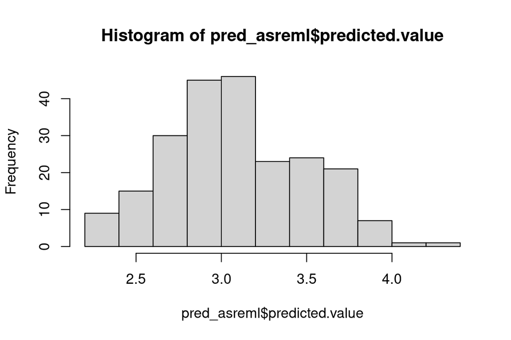

```r
hist(pred_asreml$predicted.value)
```

The model provided **genotypic predictions (BLUPs)** and **BLUEs** for fixed effects, which were used for further comparison with Bayesian results.

### Bayesian One-Stage Model (BGLR)

A Bayesian one-stage genomic prediction model was implemented using the **BGLR** package. The model included fixed environmental effects and random genomic and interaction effects.

$$y = Xb + Zu + e$$

where:

- Xb includes fixed effects for **Year** and **Block**.
- Zu includes random effects for the genomic component (modeled using RKHS) and **G×Y** interaction effects (modeled using BRR).
- e denotes residual errors.

```r
library(BGLR)

ZG  <- model.matrix(~ 0 + id, data = df_sorted)
ZY  <- model.matrix(~ 0 + Year, data = df_sorted)
ZB  <- model.matrix(~ 0 + Block, data = df_sorted)
df_sorted$GxY <- interaction(df_sorted$id, df_sorted$Year)
ZGY <- model.matrix(~ 0 + GxY, data = df_sorted)
ZK  <- G[df_sorted$id, df_sorted$id]

ETA <- list(
  G_grm = list(K = ZK, model = "RKHS"),
  Year  = list(X = ZY, model = "FIXED"),
  Block = list(X = ZB, model = "FIXED"),
  GxY   = list(X = ZGY, model = "BRR")
)

fit <- BGLR(y = df_sorted$y,
            ETA = ETA,
            nIter = 5600,
            burnIn = 200,
            verbose = TRUE)

df_sorted$yHat_BGLR <- fit$yHat

genotype_predicted_means2 <- df_sorted %>%
  group_by(id) %>%
  summarise(mean_yHat = mean(yHat_BGLR, na.rm = TRUE))
```

Some summary statistics

```r
## Variance components
# Genomic effect (RKHS)
var_G <- read.table("/home/felipe/Dropbox (UFL)/classes/Molecular_Breeding/class6_GS/BayesianAlphabet/outputs_BGLR/ETA_G_grm_varU.dat")[,1]
# Genotype × Year interaction (BRR)
var_GxY <- read.table("/home/felipe/Dropbox (UFL)/classes/Molecular_Breeding/class6_GS/BayesianAlphabet/outputs_BGLR/ETA_GxY_varB.dat")[,1]
# Residual variance
var_E <- read.table("/home/felipe/Dropbox (UFL)/classes/Molecular_Breeding/class6_GS/BayesianAlphabet/outputs_BGLR/varE.dat")[,1]

# Summary statistics
summary_var <- data.frame(
  Component = c("Genomic (RKHS)", "GxY (BRR)", "Residual"),
  Mean = c(mean(var_G), mean(var_GxY), mean(var_E)),
  Median = c(median(var_G), median(var_GxY), median(var_E)),
  CI_lower = c(quantile(var_G, 0.025), quantile(var_GxY, 0.025), quantile(var_E, 0.025)),
  CI_upper = c(quantile(var_G, 0.975), quantile(var_GxY, 0.975), quantile(var_E, 0.975))
)

summary_var
```

```
##        Component      Mean    Median  CI_lower  CI_upper
## 1 Genomic (RKHS) 0.1493658 0.1435102 0.0549952 0.2812719
## 2      GxY (BRR) 1.2026187 1.1983250 1.0239934 1.4137840
## 3       Residual 1.4252407 1.4230850 1.3303538 1.5307059
```

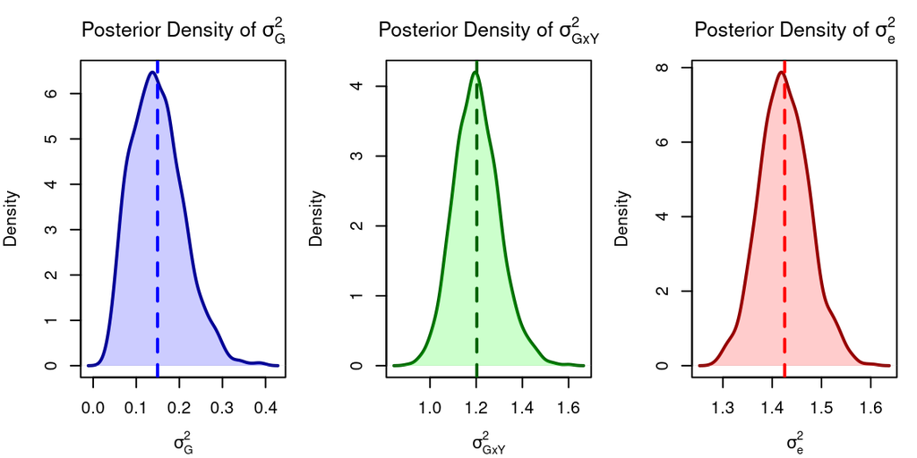

```r
# Set up plotting area: 1 row × 3 columns
par(mfrow = c(1, 3), mar = c(4, 4, 3, 1))

# Genomic variance
plot(density(var_G),
     main = expression(paste("Posterior Density of ", sigma[G]^2)),
     xlab = expression(sigma[G]^2),
     col = "darkblue",
     lwd = 2)
polygon(density(var_G), col = rgb(0, 0, 1, 0.2), border = NA)
abline(v = mean(var_G), col = "blue", lwd = 2, lty = 2)

# GxY variance
plot(density(var_GxY),
     main = expression(paste("Posterior Density of ", sigma[GxY]^2)),
     xlab = expression(sigma[GxY]^2),
     col = "darkgreen",
     lwd = 2)
polygon(density(var_GxY), col = rgb(0, 1, 0, 0.2), border = NA)
abline(v = mean(var_GxY), col = "darkgreen", lwd = 2, lty = 2)

# Residual variance
plot(density(var_E),
     main = expression(paste("Posterior Density of ", sigma[e]^2)),
     xlab = expression(sigma[e]^2),
     col = "darkred",
     lwd = 2)
polygon(density(var_E), col = rgb(1, 0, 0, 0.2), border = NA)
abline(v = mean(var_E), col = "red", lwd = 2, lty = 2)
```

The predicted means were compared with ASReml predictions:

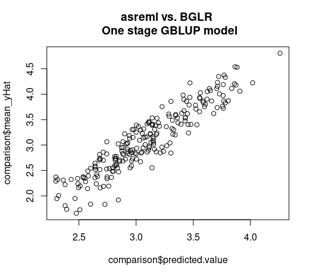

```r
comparison <- merge(pred_asreml, genotype_predicted_means2, by = "id")
plot(comparison$predicted.value, comparison$mean_yHat,main="asreml vs. BGLR \n One stage GBLUP model")
```

### Two-Stage Bayesian Analysis (BGLR)

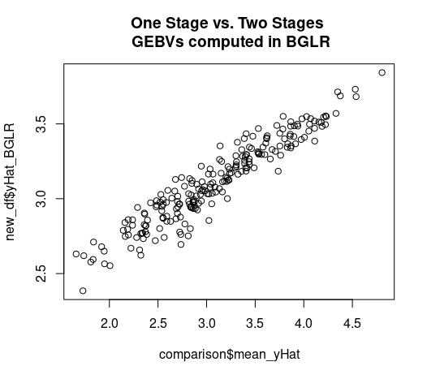

```r
new_df <- df_sorted %>%
  group_by(id) %>%
  summarise_if(is.numeric, mean, na.rm = TRUE)

fm2 <- BGLR(
  y = new_df$y,
  ETA = list(G = list(K = G, model = "RKHS")),
  nIter = 5600,
  burnIn = 200,
  verbose = TRUE,
  saveAt = "BGLR_TwoStages"
)

new_df$yHat_BGLR <- fm2$yHat
plot(comparison$mean_yHat, new_df$yHat_BGLR,main="One Stage vs. Two Stages \n GEBVs computed in BGLR")
```

### Summary of Analytical Workflow

[output not shown]

# Final consideration

# References

- Endelman, J.B. (2011). Ridge regression and other kernels for genomic selection with R package rrBLUP. The Plant Genome, 4:250–255. doi:10.3835/plantgenome2011.08.0024.
- Endelman, J.B. & Jannink, J.-L. (2012). Shrinkage estimation of the realized relationship matrix. G3: Genes, Genomes, Genetics, 2:1405–1413. doi:10.1534/g3.112.004259
- Van Raden, P.M. (2008). Efficient methods to compute genomic predictions. Journal of Dairy Science, 91:4414–4423. doi:10.3168/jds.2007-0980.